# TChroNetR Vignette

# Introduction

`TChroNetR` is designed for the construction and analysis of threshold-based chromatin networks. This package allows users to investigate chromatin networks to detect communities, select robust parameters, and perform downstream functional analyses—including genomic annotation, target gene identification via GREAT and Transcription Factors inference.

# 1. Building a TChroNet Series Object

The analysis typically begins by creating a `TChroNetSeries` object. This object acts as a container for network metrics computed across a range of thresholds. By setting `run_cd = TRUE`, the package automatically performs community detection using the **Leiden algorithm** for every resolution specified in the `resolutions_list`.

```r
library(TChroNetR)
```

```r
# Path to the normalized count matrix
matrix_path <- "~/T-ChroNet/toy_data/data/thp1_test.tsv"

# Build the TChroNet series object
obj_series <- build_TChroNetSeries_object(
  "~/T-ChroNet/toy_data/results/th/",
  matrix_path,
  resolutions_list = seq(0.5, 1.5, 0.1),
  run_cd = TRUE,
  seed = 1234,
  transitivity = FALSE
)
```

# 2. Selecting the Optimal Threshold

A critical step in network analysis is identifying an optimal threshold (*T*) that ensures biological relevance while maintaining structural integrity. The `find_best_th` function automates this selection by identifying a “transition point” based on the relative size of the largest connected component (rLCC).

By prioritizing the rLCC, `TChroNetR` encourages the analysis of well-connected networks. However, the package remains flexible:

- **Connectivity:** Lower thresholds focus on the most robust, connected interactions.
- **Inclusivity:** At higher thresholds, all nodes (including isolated ones) are incorporated. This allows users to inspect **disconnected networks**, which may be biologically significant in contexts such as heterogeneous cell populations or sparse interaction landscapes.

#### Alternative Metrics: Transitivity

If computed during the series construction phase, **transitivity** (the clustering coefficient or frequency of triangles) can also serve as a selection criterion. Since transitivity measures the network’s inherent tendency to form tightly knit groups, it is an excellent proxy for a network’s “community-building” potential.

> **Note:** Calculating transitivity is computationally intensive and may significantly increase the time required to build the `TChroNetSeries` object.

```r
# Automatically determine the best threshold parameter
obj_series@best_th <- find_best_th(obj_series)
```

# 3. Visualizing Community Detection Results

`TChroNetR` provides a suite of visualization tools to compare community structures across different thresholds (*T*) and resolutions (*R*). These plots allow for a qualitative and quantitative inspection of network stability.

## Adjusted Rand Index Map

The **Adjusted Rand Index (ARI) Map** allows users to evaluate the similarity between communities across adjacent parameters. The function calculates the ARI between neighboring cells in the threshold-resolution grid. For example, communities found at $(T=0.8, R=0.1)$ are compared against their neighbors:

- **Resolution neighbors:** $(0.8, 0.2)$
- **Threshold neighbors:** $(0.9, 0.1)$
- **Diagonal neighbors:** $(0.9, 0.2)$

High ARI values indicate regions of parameter stability.

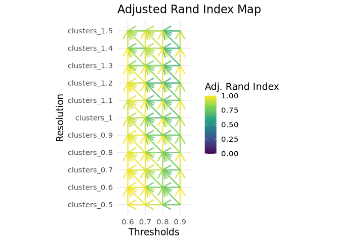

```r
plot_randindex_map(obj_series)
```

## Community Stability via Sankey Diagrams

Sankey diagrams are useful for tracking how nodes migrate between communities as parameters change. You can visualize these transitions by holding one parameter constant:

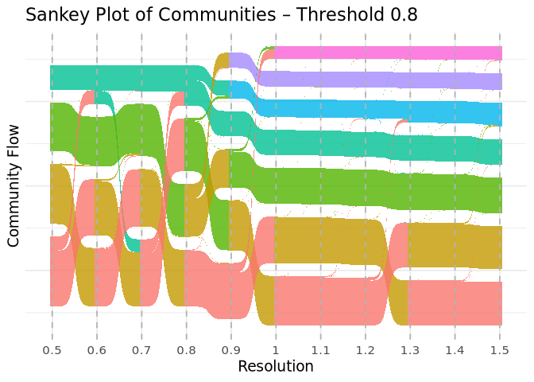

```r
# Visualize community flow across resolutions at a fixed threshold
plot_community_sankey(obj_series,
                      threshold = 0.8
                      )
```

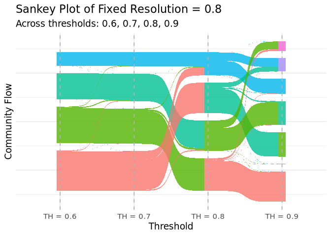

```r
# Visualize community flow across thresholds at a fixed resolution
plot_sankey_fixed_resolution(obj_series,
                            resolution = 0.8
                            )
```

# 4. Building a TChroNet Object

Once the optimal parameters are identified, the series object can be converted into a focused `TChroNet` object for downstream analysis.

```r
# Build the final TChroNet object
obj <- build_TCrhoNetNetwork_from_series(obj_series,
                                        threshold = 0.8
                                        )
```

Alternatively, if you already have a target threshold, you can bypass the series step and build the object directly.

```r
# Directly build TChroNet object without scanning thresholds
obj <- make_TChroNetNetwork_obj(
  edge_files,
  matrix_path,
  threshold = 0.8
  )
```

# 5. Community Detection Across Resolutions

By default, a `TChroNet` object inherits the community assignments stored within the `TChroNetSeries` object. However, if the `run_cd = TRUE` parameter was not utilized during the initial series construction, or if you wish to explore a different parameter space, you can perform community detection on the specific network.

The `compute_membership_nodes` function allows you to execute the Leiden algorithm at a single resolution or across a range of resolutions ($R$). This flexibility is essential for fine-tuning the granularity of the detected clusters.

```r
# Compute memberships across multiple resolutions
obj <- compute_membership_nodes(obj,
                                resolutions = seq(0.5, 1.5, 0.1)
                                )
```

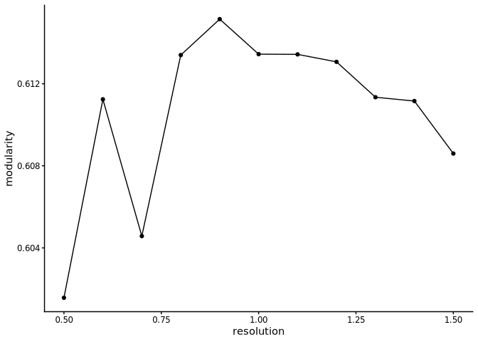

```r
# Evaluate modularity to find the best resolution
plot_modularity(obj)
```

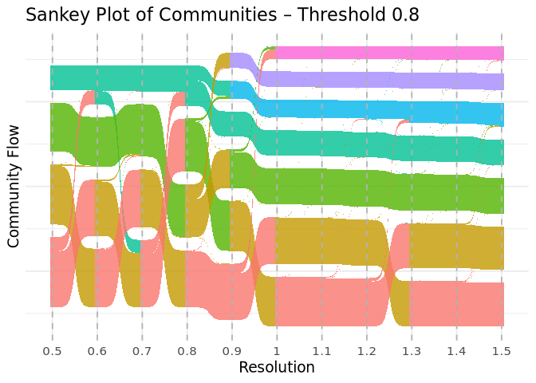

```r
# Plot the community flow at the selected thresholds for the range of resolutions stored in TChroNet object
plot_community_sankey(obj ,
                      threshold = 0.8
                      )
```

```r
# Automatically select and set the best resolution
obj <- find_best_resolution(obj)
```

# 6. Visualizing Community Trends

To understand the quantitative behavior of the detected communities, you can plot their trends (e.g., z-scores of chromatin activity) across samples.

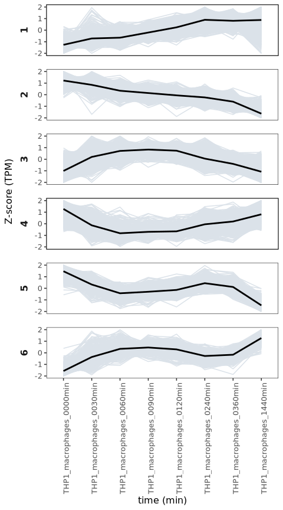

```r
# Plot trends as lines
plot_line_trends_zscore(obj)
```

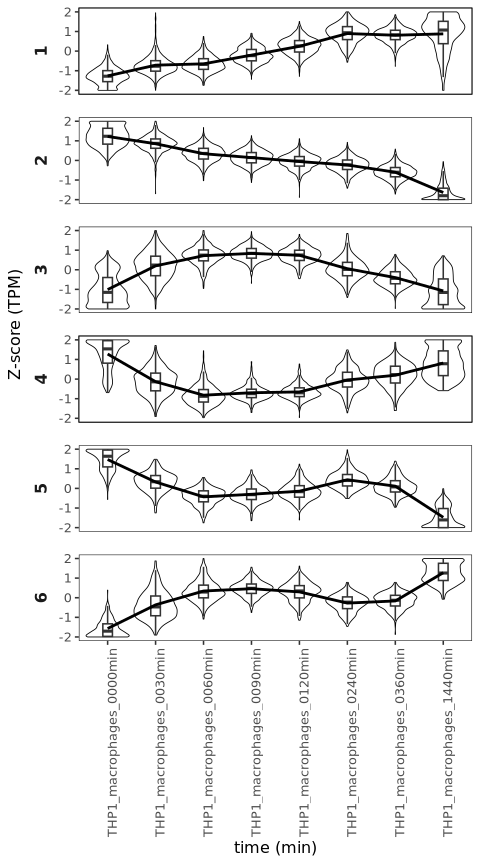

```r
# Plot trends as violin
plot_trends_zscore(obj)
```

# 7. Genomic Annotation

`TChroNetR` facilitates the annotation of network nodes with genomic features. If your network coordinates use a different assembly (e.g., **hg19**), you can perform a `liftOver` to **hg38** before annotating against databases like SCREEN cCREs. The annotations and liftover chain are stored inside the ghithub repository.

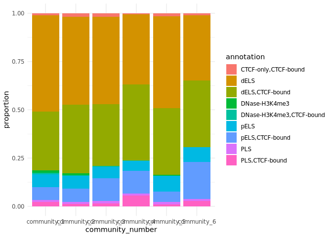

```r
# Lift hg19 to hg38 if required
obj <- lift_network_coordinates(obj,
                                chain_path = "~/T-ChroNet/toy_data/data/hg19ToHg38.over.chain"
                                )

# Annotate with SCREEN cCRE database
obj <- annotate_regions_from_bed(obj,
                                bed_path =  "~/T-ChroNet/toy_data/data/GRCh38-cCREs.bed" , genome = "hg38"
                                )

# Visualize the distribution of genomic annotations across communities
plot_stacked_annotation(obj)
```

# 8. Profiling Community Characteristics

To determine if the identified communities represent distinct biological features $rather than merely reflecting broader signal trends$ TChroNetR provides the `profile_community_biology` function. This tool annotates each genomic region within the network with key architectural and evolutionary metrics. By calling this function, users obtain a comprehensive data frame containing region length, GC content, distance to the nearest Transcription Start Site (TSS), and phylogenetic conservation scores. These metrics are essential for validating whether specific communities are enriched for certain biological properties, such as promoter-proximal elements or highly conserved regulatory regions.

```r
# import libraries for hg 38 genome
library(BSgenome.Hsapiens.UCSC.hg38)
library(phastCons100way.UCSC.hg38)
library(TxDb.Hsapiens.UCSC.hg38.knownGene)

communities_profilation <- profile_community_biology(obj,
                                                      genome = BSgenome.Hsapiens.UCSC.hg38::BSgenome.Hsapiens.UCSC.hg38,
                                                      phast = phastCons100way.UCSC.hg38::phastCons100way.UCSC.hg38,
                                                      txdb = TxDb.Hsapiens.UCSC.hg38.knownGene::TxDb.Hsapiens.UCSC.hg38.knownGene
                                                      )
```

# 9. Target Gene Identification

To interpret the biological role of each community, `TChroNetR` interfaces with **rGREAT**. This identifies enriched functions and potential target genes for the genomic regions within each cluster.

```r
# Run GREAT functional analysis on the communities
obj <- run_GREAT_analysis(obj, genome = 'hg19')
```

# 10. Transcription Factors Identification

To understand the regulatory drivers behind each community, `TChroNetR` integrates with the `monaLisa` package to perform Transcription Factor (TF) motif enrichment analysis. This step identifies which motifs are significantly overrepresented in the genomic regions of specific communities compared to a background set.

### Loading Motif Databases

First, we retrieve the Position Weight Matrices (PWMs) from the **JASPAR2024** database. In this example, we focus on the vertebrate “CORE” collection.

```r
library(JASPAR2024)
library(TFBSTools)
JASPAR2024 <- JASPAR2024()
JASPARConnect <- RSQLite::dbConnect(RSQLite::SQLite(), db(JASPAR2024))
pwms <- getMatrixSet(JASPARConnect,
                     opts = list(
                      tax_group = "vertebrates",
                      collection="CORE",
                      matrixtype = "PWM"))

# disconnect Db
RSQLite::dbDisconnect(JASPARConnect)
```

### Motif Enrichment Analysis

With the PWMs loaded, we use the `run_monalisa_enrichment` function. This function analyzes the sequences within each community at a specified resolution to find enriched motifs.

> **Tip:** Motif enrichment is computationally intensive. We recommend using the `num_cores` parameter to enable parallel processing if your system allows.

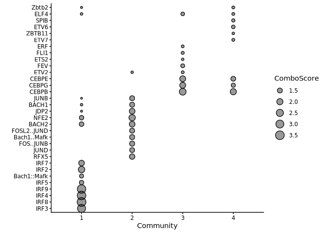

```r
# Execute motif enrichment analysis
# Adjust 'resolution' to match your selected community structure. If not specified, it uses the obj@resolution parameter
obj@TFs <- run_monalisa_enrichment(obj ,
                                  resolution = 0.8 ,
                                  pwms = pwms ,
                                  genome = "hg19" ,
                                  num_cores = 2
                                  )

# Visualize the enrichment results
plot_enrichments_tfs(obj)
```

The resulting bubble chart allows you to pinpoint specific transcription factors that may be orchestrating the chromatin interactions within distinct communities, providing a deeper layer of regulatory insight.